# Workplace-Intervention_01-Analyses

Author

SSK

Published

March 12, 2024

```r
data <- read.csv("dataFull_20240130.csv")
```

# Descriptives

**Condition**

| Condition | Freq |
| --- | --- |
| Control | 57 |
| Treatment | 56 |

**School / Division**

| School / Division | Freq |
| --- | --- |
| Goldman | 4 |
| Haas | 39 |
| Law | 39 |
| UDAR | 31 |

**Academic / Staff**

| Academic / Staff | Freq |
| --- | --- |
| Academic | 4 |
| Staff | 39 |

**Manager**

| Manager | Freq |
| --- | --- |
| No | 63 |
| Yes | 50 |

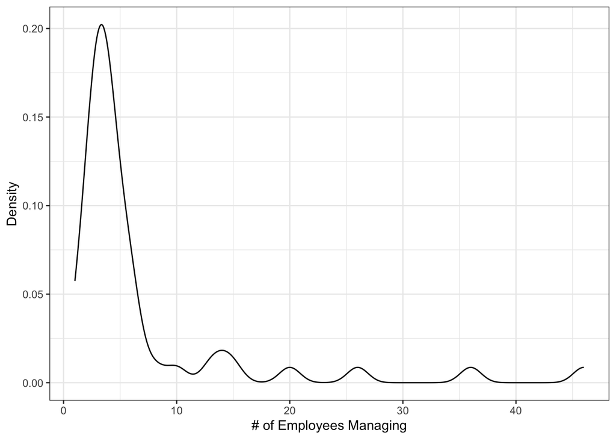

**Gender**

| Gender | Freq |
| --- | --- |
| Female | 86 |
| Genderqueer / Nonbinary | 9 |
| Male | 17 |
| Trans Male / Trans Man | 1 |

**Race**

| Race | Freq |
| --- | --- |
| African American / Black | 4 |
| Chinese | 7 |
| Filipino | 1 |
| Hispanic / Latino | 10 |
| Korean | 3 |
| Middle Eastern / SWANA | 2 |
| Other Asian | 1 |
| Two or more races | 11 |
| White | 74 |

| URM | Freq |
| --- | --- |
| 0 | 88 |
| 1 | 14 |

# High-Level Findings

**Confirmatory**

- Treatment had a significant effect on **multiple-selves / complexity beliefs**
- Treatment had a marginal effect on **relationship-prioritization** and **perspective-taking**

**Exploratory**

- Treatment had a marginal effect on **attributions** for co-worker scenario
- Treatment had no effect for outcomes for manager scenario

**Session 2**

- Treatment had a marginal / significant effect on **perspective-taking**
- Treatment had a significant effect on **beliefs about workplace relationships**
- Treatment even had significant effect on **perspective-taking in manager scenario**

# Key

| Symbol | Sig. Level | p |
| --- | --- | --- |
| 🟢 | Significant | < 0.05 |
| ️️🟡 | Marginal / Trending | 0.05 - 0.09 |
| 🔴 | Non-Significant | > 0.10 |

# Session 1

# Confirmatory

## 1. Relationship-prioritization 🟡

*How likely are you to prioritize establishing a positive relationship with every single co-worker in your workplace?*

```
    Welch Two Sample t-test

data:  data$manipTreat1 by data$Condition
t = -1.6847, df = 65.767, p-value = 0.09679
alternative hypothesis: true difference in means between group Control and group Treatment is not equal to 0
95 percent confidence interval:
 -1.6211167  0.1373958
sample estimates:
  mean in group Control mean in group Treatment
                4.55814                 5.30000
```

```
No summary function supplied, defaulting to `mean_se()`
```

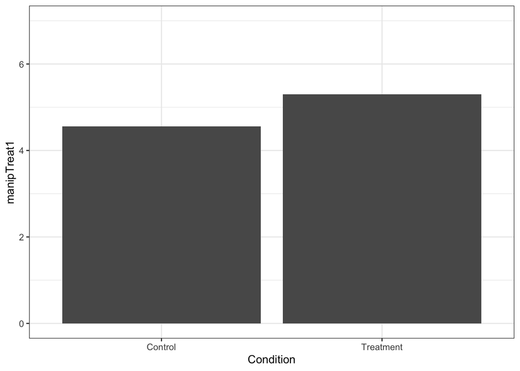

```
Call:
lm(formula = manipTreat1 ~ Condition + gender, data = data)

Residuals:
    Min      1Q  Median      3Q     Max
-4.4367 -1.3198  0.5633  1.5633  2.2176

Coefficients:
                   Estimate Std. Error t value Pr(>|t|)
(Intercept)          5.3447     0.4221  12.664   <2e-16 ***
ConditionTreatment   0.6044     0.4355   1.388    0.170
gender              -0.5125     0.2075  -2.470    0.016 *
---
Signif. codes:  0 '***' 0.001 '**' 0.01 '*' 0.05 '.' 0.1 ' ' 1

Residual standard error: 1.816 on 70 degrees of freedom
  (40 observations deleted due to missingness)
Multiple R-squared:  0.1145,    Adjusted R-squared:  0.08917
F-statistic: 4.524 on 2 and 70 DF,  p-value: 0.0142
```

```
Call:
lm(formula = manipTreat1 ~ Condition + manager_text, data = data)

Residuals:
    Min      1Q  Median      3Q     Max
-4.5871 -1.3022  0.4129  1.4129  2.6978

Coefficients:
                   Estimate Std. Error t value Pr(>|t|)
(Intercept)          4.3022     0.3720  11.566   <2e-16 ***
ConditionTreatment   0.8064     0.4507   1.789   0.0779 .
manager_textYes      0.4784     0.4438   1.078   0.2848
---
Signif. codes:  0 '***' 0.001 '**' 0.01 '*' 0.05 '.' 0.1 ' ' 1

Residual standard error: 1.878 on 70 degrees of freedom
  (40 observations deleted due to missingness)
Multiple R-squared:  0.05303,   Adjusted R-squared:  0.02598
F-statistic:  1.96 on 2 and 70 DF,  p-value: 0.1485
```

```
Call:
lm(formula = manipTreat1 ~ Condition * race_urm, data = data)

Residuals:
   Min     1Q Median     3Q    Max
-4.400 -1.333  0.600  1.541  2.364

Coefficients:
                            Estimate Std. Error t value Pr(>|t|)
(Intercept)                   4.6364     0.3364  13.784   <2e-16 ***
ConditionTreatment            0.7636     0.5123   1.491    0.141
race_urm                     -0.3030     0.8575  -0.353    0.725
ConditionTreatment:race_urm  -0.5970     1.6587  -0.360    0.720
---
Signif. codes:  0 '***' 0.001 '**' 0.01 '*' 0.05 '.' 0.1 ' ' 1

Residual standard error: 1.932 on 62 degrees of freedom
  (47 observations deleted due to missingness)
Multiple R-squared:  0.04453,   Adjusted R-squared:  -0.001702
F-statistic: 0.9632 on 3 and 62 DF,  p-value: 0.4159
```

## 2. Multiple-selves / Complexity Beliefs 🟢

*How much do you agree with the following statement?: Everyone in the workplace is complex inside and is capable of tapping into different parts of themself.*

```
    Welch Two Sample t-test

data:  data$manipTreat2_recode by data$Condition
t = -2.704, df = 67.365, p-value = 0.008666
alternative hypothesis: true difference in means between group Control and group Treatment is not equal to 0
95 percent confidence interval:
 -0.59957786 -0.09034462
sample estimates:
  mean in group Control mean in group Treatment
               4.488372                4.833333
```

```
No summary function supplied, defaulting to `mean_se()`
```

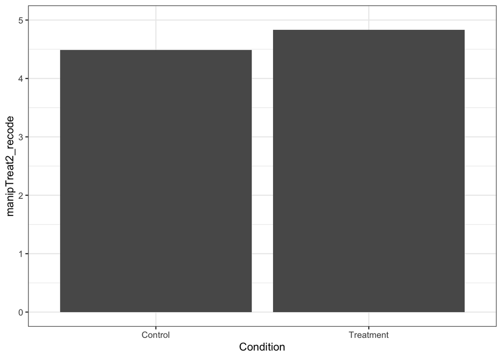

```
Call:
lm(formula = manipTreat2_recode ~ Condition + gender, data = data)

Residuals:
    Min      1Q  Median      3Q     Max
-1.4947 -0.4829  0.1635  0.5053  0.5523

Coefficients:
                   Estimate Std. Error t value Pr(>|t|)
(Intercept)         4.50640    0.13863  32.507   <2e-16 ***
ConditionTreatment  0.34181    0.14305   2.389   0.0196 *
gender             -0.01174    0.06816  -0.172   0.8637
---
Signif. codes:  0 '***' 0.001 '**' 0.01 '*' 0.05 '.' 0.1 ' ' 1

Residual standard error: 0.5964 on 70 degrees of freedom
  (40 observations deleted due to missingness)
Multiple R-squared:  0.07823,   Adjusted R-squared:  0.0519
F-statistic: 2.971 on 2 and 70 DF,  p-value: 0.05777
```

```
Call:
lm(formula = manipTreat2_recode ~ Condition + manager_text, data = data)

Residuals:
    Min      1Q  Median      3Q     Max
-1.5603 -0.4057  0.2285  0.4397  0.5943

Coefficients:
                   Estimate Std. Error t value Pr(>|t|)
(Intercept)          4.4057     0.1172  37.606   <2e-16 ***
ConditionTreatment   0.3658     0.1419   2.577   0.0121 *
manager_textYes      0.1546     0.1398   1.106   0.2725
---
Signif. codes:  0 '***' 0.001 '**' 0.01 '*' 0.05 '.' 0.1 ' ' 1

Residual standard error: 0.5914 on 70 degrees of freedom
  (40 observations deleted due to missingness)
Multiple R-squared:  0.09368,   Adjusted R-squared:  0.06779
F-statistic: 3.618 on 2 and 70 DF,  p-value: 0.03197
```

```
Call:
lm(formula = manipTreat2_recode ~ Condition * race_urm, data = data)

Residuals:
    Min      1Q  Median      3Q     Max
-1.5454 -0.5454  0.1600  0.4546  0.8333

Coefficients:
                            Estimate Std. Error t value Pr(>|t|)
(Intercept)                  4.54545    0.10574  42.988   <2e-16 ***
ConditionTreatment           0.29455    0.16105   1.829   0.0722 .
race_urm                    -0.37879    0.26958  -1.405   0.1650
ConditionTreatment:race_urm  0.03879    0.52145   0.074   0.9409
---
Signif. codes:  0 '***' 0.001 '**' 0.01 '*' 0.05 '.' 0.1 ' ' 1

Residual standard error: 0.6074 on 62 degrees of freedom
  (47 observations deleted due to missingness)
Multiple R-squared:  0.104, Adjusted R-squared:  0.06065
F-statistic: 2.399 on 3 and 62 DF,  p-value: 0.07641
```

## 3. Perspective-taking

$\alpha = 0.63$

**Per preregistration, will therefore look at items individually**

*Over the next 2 weeks while at work…*

**a. if I’m sure I’m right about something, I won’t waste much time listening to other people’s arguments. 🔴**

```
    Welch Two Sample t-test

data:  data$IRI_PT_1 by data$Condition
t = 1.4986, df = 69.991, p-value = 0.1385
alternative hypothesis: true difference in means between group Control and group Treatment is not equal to 0
95 percent confidence interval:
 -0.1008309  0.7103547
sample estimates:
  mean in group Control mean in group Treatment
               2.404762                2.100000
```

```
Call:
lm(formula = IRI_PT_1 ~ Condition + gender, data = data)

Residuals:
    Min      1Q  Median      3Q     Max
-1.5809 -0.3768 -0.0864  0.5722  1.9136

Coefficients:
                   Estimate Std. Error t value Pr(>|t|)
(Intercept)         2.32582    0.21285  10.927   <2e-16 ***
ConditionTreatment -0.29043    0.21849  -1.329    0.188
gender              0.05101    0.10372   0.492    0.624
---
Signif. codes:  0 '***' 0.001 '**' 0.01 '*' 0.05 '.' 0.1 ' ' 1

Residual standard error: 0.9059 on 69 degrees of freedom
  (41 observations deleted due to missingness)
Multiple R-squared:  0.03121,   Adjusted R-squared:  0.003125
F-statistic: 1.111 on 2 and 69 DF,  p-value: 0.3349
```

```
Call:
lm(formula = IRI_PT_1 ~ Condition + manager_text, data = data)

Residuals:
    Min      1Q  Median      3Q     Max
-1.4289 -0.4289 -0.1304  0.6218  1.9203

Coefficients:
                   Estimate Std. Error t value Pr(>|t|)
(Intercept)         2.37823    0.17990  13.220   <2e-16 ***
ConditionTreatment -0.29849    0.21847  -1.366    0.176
manager_textYes     0.05065    0.21575   0.235    0.815
---
Signif. codes:  0 '***' 0.001 '**' 0.01 '*' 0.05 '.' 0.1 ' ' 1

Residual standard error: 0.9071 on 69 degrees of freedom
  (41 observations deleted due to missingness)
Multiple R-squared:  0.02859,   Adjusted R-squared:  0.0004299
F-statistic: 1.015 on 2 and 69 DF,  p-value: 0.3677
```

```
Call:
lm(formula = IRI_PT_1 ~ Condition * race_urm, data = data)

Residuals:
    Min      1Q  Median      3Q     Max
-1.4375 -0.4375 -0.0800  0.5625  1.9200

Coefficients:
                            Estimate Std. Error t value Pr(>|t|)
(Intercept)                   2.4375     0.1471  16.575   <2e-16 ***
ConditionTreatment           -0.3575     0.2221  -1.610    0.113
race_urm                     -0.4375     0.3701  -1.182    0.242
ConditionTreatment:race_urm   0.8575     0.7146   1.200    0.235
---
Signif. codes:  0 '***' 0.001 '**' 0.01 '*' 0.05 '.' 0.1 ' ' 1

Residual standard error: 0.8319 on 61 degrees of freedom
  (48 observations deleted due to missingness)
Multiple R-squared:  0.05249,   Adjusted R-squared:  0.005896
F-statistic: 1.127 on 3 and 61 DF,  p-value: 0.3454
```

**b. I will sometimes try to understand my coworkers better by imagining howthings look from their perspective. 🔴**

```
    Welch Two Sample t-test

data:  data$IRI_PT_2 by data$Condition
t = -0.62738, df = 52.819, p-value = 0.5331
alternative hypothesis: true difference in means between group Control and group Treatment is not equal to 0
95 percent confidence interval:
 -0.4197252  0.2197252
sample estimates:
  mean in group Control mean in group Treatment
               4.333333                4.433333
```

```
Call:
lm(formula = IRI_PT_2 ~ Condition + gender, data = data)

Residuals:
     Min       1Q   Median       3Q      Max
-2.48275 -0.43481  0.00448  0.52924  0.75049

Coefficients:
                   Estimate Std. Error t value Pr(>|t|)
(Intercept)         4.62011    0.14446  31.981   <2e-16 ***
ConditionTreatment  0.04794    0.14829   0.323   0.7475
gender             -0.18530    0.07040  -2.632   0.0105 *
---
Signif. codes:  0 '***' 0.001 '**' 0.01 '*' 0.05 '.' 0.1 ' ' 1

Residual standard error: 0.6148 on 69 degrees of freedom
  (41 observations deleted due to missingness)
Multiple R-squared:  0.09676,   Adjusted R-squared:  0.07058
F-statistic: 3.696 on 2 and 69 DF,  p-value: 0.02987
```

```
Call:
lm(formula = IRI_PT_2 ~ Condition + manager_text, data = data)

Residuals:
    Min      1Q  Median      3Q     Max
-2.3096 -0.4806 -0.1713  0.5194  0.8287

Coefficients:
                   Estimate Std. Error t value Pr(>|t|)
(Intercept)          4.1713     0.1241  33.618   <2e-16 ***
ConditionTreatment   0.1383     0.1507   0.918   0.3620
manager_textYes      0.3093     0.1488   2.078   0.0414 *
---
Signif. codes:  0 '***' 0.001 '**' 0.01 '*' 0.05 '.' 0.1 ' ' 1

Residual standard error: 0.6257 on 69 degrees of freedom
  (41 observations deleted due to missingness)
Multiple R-squared:  0.06461,   Adjusted R-squared:  0.0375
F-statistic: 2.383 on 2 and 69 DF,  p-value: 0.09982
```

```
Call:
lm(formula = IRI_PT_2 ~ Condition * race_urm, data = data)

Residuals:
    Min      1Q  Median      3Q     Max
-2.4000 -0.3333 -0.3125  0.6000  0.6875

Coefficients:
                            Estimate Std. Error t value Pr(>|t|)
(Intercept)                  4.31250    0.11697  36.868   <2e-16 ***
ConditionTreatment           0.08750    0.17662   0.495    0.622
race_urm                     0.02083    0.29437   0.071    0.944
ConditionTreatment:race_urm  0.07917    0.56841   0.139    0.890
---
Signif. codes:  0 '***' 0.001 '**' 0.01 '*' 0.05 '.' 0.1 ' ' 1

Residual standard error: 0.6617 on 61 degrees of freedom
  (48 observations deleted due to missingness)
Multiple R-squared:  0.005704,  Adjusted R-squared:  -0.0432
F-statistic: 0.1166 on 3 and 61 DF,  p-value: 0.95
```

**c. I will believe that there are two sides to every question and try to look at them both. 🔴**

```
    Welch Two Sample t-test

data:  data$IRI_PT_3 by data$Condition
t = -0.88515, df = 68.492, p-value = 0.3792
alternative hypothesis: true difference in means between group Control and group Treatment is not equal to 0
95 percent confidence interval:
 -0.573341  0.220960
sample estimates:
  mean in group Control mean in group Treatment
                4.02381                 4.20000
```

```
Call:
lm(formula = IRI_PT_3 ~ Condition + gender, data = data)

Residuals:
     Min       1Q   Median       3Q      Max
-2.21450 -0.21450 -0.05359  0.78550  1.16393

Coefficients:
                   Estimate Std. Error t value Pr(>|t|)
(Intercept)         4.10797    0.20310  20.226   <2e-16 ***
ConditionTreatment  0.16091    0.20848   0.772    0.443
gender             -0.05438    0.09897  -0.549    0.584
---
Signif. codes:  0 '***' 0.001 '**' 0.01 '*' 0.05 '.' 0.1 ' ' 1

Residual standard error: 0.8644 on 69 degrees of freedom
  (41 observations deleted due to missingness)
Multiple R-squared:  0.01469,   Adjusted R-squared:  -0.01387
F-statistic: 0.5145 on 2 and 69 DF,  p-value: 0.6001
```

```
Call:
lm(formula = IRI_PT_3 ~ Condition + manager_text, data = data)

Residuals:
     Min       1Q   Median       3Q      Max
-2.16056 -0.37231 -0.08513  0.83944  1.12662

Coefficients:
                   Estimate Std. Error t value Pr(>|t|)
(Intercept)          3.8734     0.1694  22.871   <2e-16 ***
ConditionTreatment   0.2117     0.2057   1.029    0.307
manager_textYes      0.2872     0.2031   1.414    0.162
---
Signif. codes:  0 '***' 0.001 '**' 0.01 '*' 0.05 '.' 0.1 ' ' 1

Residual standard error: 0.854 on 69 degrees of freedom
  (41 observations deleted due to missingness)
Multiple R-squared:  0.03825,   Adjusted R-squared:  0.01037
F-statistic: 1.372 on 2 and 69 DF,  p-value: 0.2604
```

```
Call:
lm(formula = IRI_PT_3 ~ Condition * race_urm, data = data)

Residuals:
     Min       1Q   Median       3Q      Max
-2.16000 -0.16000 -0.03125  0.84000  1.00000

Coefficients:
                            Estimate Std. Error t value Pr(>|t|)
(Intercept)                  4.03125    0.15735  25.620   <2e-16 ***
ConditionTreatment           0.12875    0.23759   0.542    0.590
race_urm                    -0.03125    0.39599  -0.079    0.937
ConditionTreatment:race_urm -0.12875    0.76461  -0.168    0.867
---
Signif. codes:  0 '***' 0.001 '**' 0.01 '*' 0.05 '.' 0.1 ' ' 1

Residual standard error: 0.8901 on 61 degrees of freedom
  (48 observations deleted due to missingness)
Multiple R-squared:  0.005896,  Adjusted R-squared:  -0.04299
F-statistic: 0.1206 on 3 and 61 DF,  p-value: 0.9476
```

**d. I will try to look at everybody’s side of a disagreement before I make a decision. 🟡**

```
    Welch Two Sample t-test

data:  data$IRI_PT_4 by data$Condition
t = -1.8145, df = 68.511, p-value = 0.07398
alternative hypothesis: true difference in means between group Control and group Treatment is not equal to 0
95 percent confidence interval:
 -0.71451245  0.03389229
sample estimates:
  mean in group Control mean in group Treatment
               4.093023                4.433333
```

```
No summary function supplied, defaulting to `mean_se()`
```

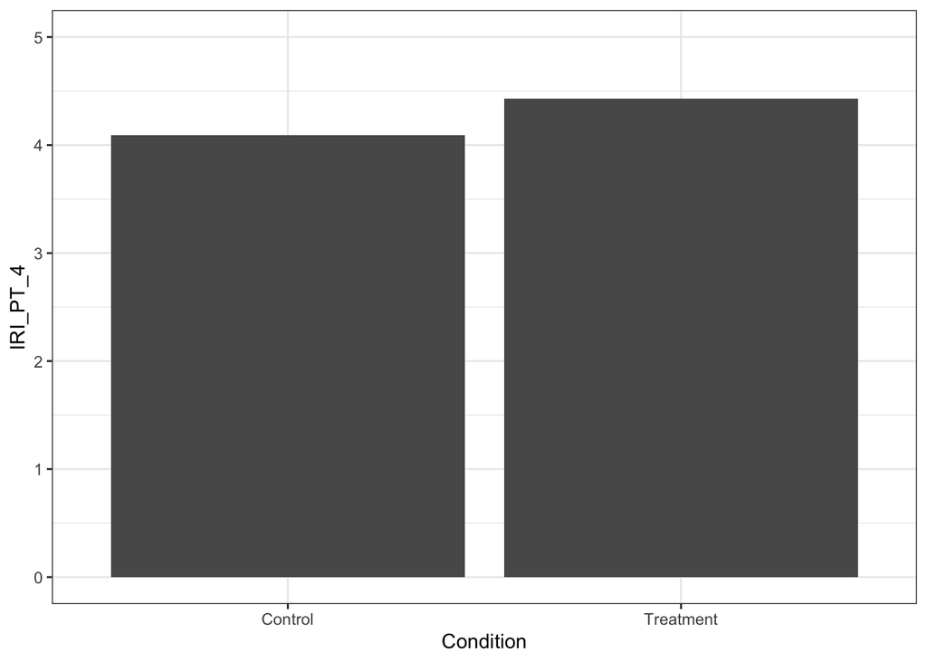

```
Call:
lm(formula = IRI_PT_4 ~ Condition + gender, data = data)

Residuals:
     Min       1Q   Median       3Q      Max
-2.43544 -0.43544 -0.08934  0.56456  0.93441

Coefficients:
                    Estimate Std. Error t value Pr(>|t|)
(Intercept)         4.105176   0.190437  21.557   <2e-16 ***
ConditionTreatment  0.338186   0.196515   1.721   0.0897 .
gender             -0.007918   0.093635  -0.085   0.9329
---
Signif. codes:  0 '***' 0.001 '**' 0.01 '*' 0.05 '.' 0.1 ' ' 1

Residual standard error: 0.8193 on 70 degrees of freedom
  (40 observations deleted due to missingness)
Multiple R-squared:  0.04183,   Adjusted R-squared:  0.01445
F-statistic: 1.528 on 2 and 70 DF,  p-value: 0.2241
```

```
Call:
lm(formula = IRI_PT_4 ~ Condition + manager_text, data = data)

Residuals:
    Min      1Q  Median      3Q     Max
-2.3962 -0.3962 -0.0434  0.6038  0.9566

Coefficients:
                   Estimate Std. Error t value Pr(>|t|)
(Intercept)         4.04340    0.16204  24.952   <2e-16 ***
ConditionTreatment  0.35282    0.19633   1.797   0.0766 .
manager_textYes     0.09278    0.19336   0.480   0.6329
---
Signif. codes:  0 '***' 0.001 '**' 0.01 '*' 0.05 '.' 0.1 ' ' 1

Residual standard error: 0.818 on 70 degrees of freedom
  (40 observations deleted due to missingness)
Multiple R-squared:  0.04487,   Adjusted R-squared:  0.01758
F-statistic: 1.644 on 2 and 70 DF,  p-value: 0.2005
```

```
Call:
lm(formula = IRI_PT_4 ~ Condition * race_urm, data = data)

Residuals:
    Min      1Q  Median      3Q     Max
-2.4000 -0.4000 -0.1212  0.6000  1.1667

Coefficients:
                            Estimate Std. Error t value Pr(>|t|)
(Intercept)                   4.1212     0.1447  28.478   <2e-16 ***
ConditionTreatment            0.2788     0.2204   1.265    0.211
race_urm                     -0.2879     0.3690  -0.780    0.438
ConditionTreatment:race_urm   0.3879     0.7137   0.543    0.589
---
Signif. codes:  0 '***' 0.001 '**' 0.01 '*' 0.05 '.' 0.1 ' ' 1

Residual standard error: 0.8313 on 62 degrees of freedom
  (47 observations deleted due to missingness)
Multiple R-squared:  0.04845,   Adjusted R-squared:  0.00241
F-statistic: 1.052 on 3 and 62 DF,  p-value: 0.3759
```

# Exploratory

## Scenario 1

**You just started a new role as a manager. You regularly try to meet with your new employees both as a team and one-on-one to get to know them and to give them the opportunity to get to know you. In general, you have built a good rapport with many of them and they seem to like your leadership style. However, after a few weeks, you notice that one of your employees has seemed to do the bare minimum with some work duties and doesn’t seem mentally present in meetings. From what you have heard, this employee tended to go above and beyond in their work before you started your new role.**

### Attributions 🟡

```
    Welch Two Sample t-test

data:  data$attributions_1 by data$Condition
t = -1.7784, df = 65.364, p-value = 0.07998
alternative hypothesis: true difference in means between group Control and group Treatment is not equal to 0
95 percent confidence interval:
 -0.66578906  0.03853126
sample estimates:
  mean in group Control mean in group Treatment
               3.238095                3.551724
```

```
No summary function supplied, defaulting to `mean_se()`
```

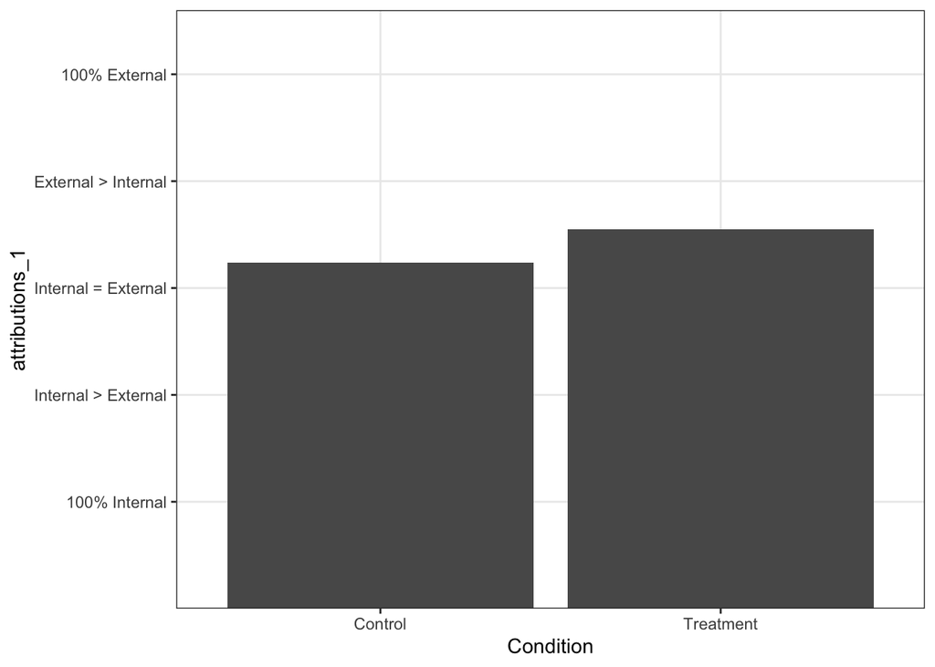

```
Call:
lm(formula = attributions_1 ~ Condition + gender, data = data)

Residuals:
   Min     1Q Median     3Q    Max
-2.243 -0.394 -0.234  0.463  1.757

Coefficients:
                    Estimate Std. Error t value Pr(>|t|)
(Intercept)         3.251120   0.175914  18.481   <2e-16 ***
ConditionTreatment  0.311510   0.183599   1.697   0.0943 .
gender             -0.008547   0.086478  -0.099   0.9216
---
Signif. codes:  0 '***' 0.001 '**' 0.01 '*' 0.05 '.' 0.1 ' ' 1

Residual standard error: 0.7552 on 68 degrees of freedom
  (42 observations deleted due to missingness)
Multiple R-squared:  0.04182,   Adjusted R-squared:  0.01364
F-statistic: 1.484 on 2 and 68 DF,  p-value: 0.234
```

```
Call:
lm(formula = attributions_1 ~ Condition + manager_text, data = data)

Residuals:
     Min       1Q   Median       3Q      Max
-2.09252 -0.41431 -0.09252  0.58569  1.90748

Coefficients:
                   Estimate Std. Error t value Pr(>|t|)
(Intercept)          3.4143     0.1498  22.798   <2e-16 ***
ConditionTreatment   0.2595     0.1806   1.437   0.1554
manager_textYes     -0.3218     0.1777  -1.811   0.0746 .
---
Signif. codes:  0 '***' 0.001 '**' 0.01 '*' 0.05 '.' 0.1 ' ' 1

Residual standard error: 0.7377 on 68 degrees of freedom
  (42 observations deleted due to missingness)
Multiple R-squared:  0.08577,   Adjusted R-squared:  0.05888
F-statistic:  3.19 on 2 and 68 DF,  p-value: 0.04742
```

```
Call:
lm(formula = attributions_1 ~ Condition * race_urm, data = data)

Residuals:
    Min      1Q  Median      3Q     Max
-2.3030 -0.4167 -0.3030  0.5833  1.6970

Coefficients:
                            Estimate Std. Error t value Pr(>|t|)
(Intercept)                   3.3030     0.1287  25.662  < 2e-16 ***
ConditionTreatment            0.1136     0.1984   0.573  0.56887
race_urm                     -0.3030     0.3548  -0.854  0.39651
ConditionTreatment:race_urm   1.8864     0.6497   2.904  0.00515 **
---
Signif. codes:  0 '***' 0.001 '**' 0.01 '*' 0.05 '.' 0.1 ' ' 1

Residual standard error: 0.7394 on 60 degrees of freedom
  (49 observations deleted due to missingness)
Multiple R-squared:  0.1589,    Adjusted R-squared:  0.1168
F-statistic: 3.778 on 3 and 60 DF,  p-value: 0.01499
```

```
No summary function supplied, defaulting to `mean_se()`
No summary function supplied, defaulting to `mean_se()`
```

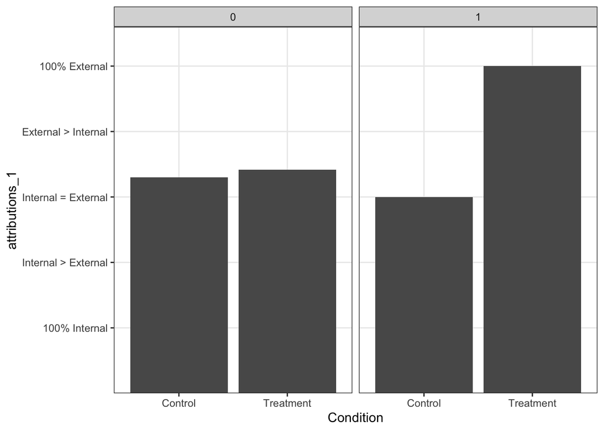

### Perspective-Taking 🔴

```r
t.test(data$IRI_PT1_1 ~ data$Condition)
```

```
    Welch Two Sample t-test

data:  data$IRI_PT1_1 by data$Condition
t = -0.64391, df = 64.238, p-value = 0.5219
alternative hypothesis: true difference in means between group Control and group Treatment is not equal to 0
95 percent confidence interval:
 -0.5549497  0.2843927
sample estimates:
  mean in group Control mean in group Treatment
               3.692308                3.827586
```

```r
summary(lm(IRI_PT1_1 ~ Condition + gender, data))
```

```
Call:
lm(formula = IRI_PT1_1 ~ Condition + gender, data = data)

Residuals:
    Min      1Q  Median      3Q     Max
-1.9031 -0.6469  0.2012  0.3532  1.3532

Coefficients:
                   Estimate Std. Error t value Pr(>|t|)
(Intercept)          3.5426     0.2110  16.788   <2e-16 ***
ConditionTreatment   0.1520     0.2153   0.706    0.483
gender               0.1043     0.1099   0.949    0.346
---
Signif. codes:  0 '***' 0.001 '**' 0.01 '*' 0.05 '.' 0.1 ' ' 1

Residual standard error: 0.8749 on 65 degrees of freedom
  (45 observations deleted due to missingness)
Multiple R-squared:  0.01958,   Adjusted R-squared:  -0.01059
F-statistic: 0.6491 on 2 and 65 DF,  p-value: 0.5259
```

```r
summary(lm(IRI_PT1_1 ~ Condition + manager_text, data))
```

```
Call:
lm(formula = IRI_PT1_1 ~ Condition + manager_text, data = data)

Residuals:
    Min      1Q  Median      3Q     Max
-1.8462 -0.6752  0.1855  0.3248  1.3248

Coefficients:
                   Estimate Std. Error t value Pr(>|t|)
(Intercept)         3.67523    0.18260  20.128   <2e-16 ***
ConditionTreatment  0.13923    0.21764   0.640    0.525
manager_textYes     0.03172    0.21537   0.147    0.883
---
Signif. codes:  0 '***' 0.001 '**' 0.01 '*' 0.05 '.' 0.1 ' ' 1

Residual standard error: 0.8808 on 65 degrees of freedom
  (45 observations deleted due to missingness)
Multiple R-squared:  0.006329,  Adjusted R-squared:  -0.02425
F-statistic: 0.207 on 2 and 65 DF,  p-value: 0.8135
```

```r
summary(lm(IRI_PT1_1 ~ Condition * race_urm, data))
```

```
Call:
lm(formula = IRI_PT1_1 ~ Condition * race_urm, data = data)

Residuals:
    Min      1Q  Median      3Q     Max
-1.7667 -0.5000  0.2333  0.2500  1.6000

Coefficients:
                            Estimate Std. Error t value Pr(>|t|)
(Intercept)                  3.76667    0.16324  23.074   <2e-16 ***
ConditionTreatment          -0.01667    0.24486  -0.068    0.946
race_urm                    -0.36667    0.43189  -0.849    0.399
ConditionTreatment:race_urm  1.11667    0.78711   1.419    0.161
---
Signif. codes:  0 '***' 0.001 '**' 0.01 '*' 0.05 '.' 0.1 ' ' 1

Residual standard error: 0.8941 on 57 degrees of freedom
  (52 observations deleted due to missingness)
Multiple R-squared:  0.03688,   Adjusted R-squared:  -0.01381
F-statistic: 0.7275 on 3 and 57 DF,  p-value: 0.5398
```

```r
t.test(data$IRI_PT2_1 ~ data$Condition)
```

```
    Welch Two Sample t-test

data:  data$IRI_PT2_1 by data$Condition
t = -0.44529, df = 61.926, p-value = 0.6577
alternative hypothesis: true difference in means between group Control and group Treatment is not equal to 0
95 percent confidence interval:
 -0.5096101  0.3239337
sample estimates:
  mean in group Control mean in group Treatment
               3.769231                3.862069
```

```r
summary(lm(IRI_PT2_1 ~ Condition + gender, data))
```

```
Call:
lm(formula = IRI_PT2_1 ~ Condition + gender, data = data)

Residuals:
     Min       1Q   Median       3Q      Max
-1.91950 -0.07826  0.15981  0.26534  1.26534

Coefficients:
                   Estimate Std. Error t value Pr(>|t|)
(Intercept)          3.6554     0.2072  17.642   <2e-16 ***
ConditionTreatment   0.1055     0.2114   0.499    0.619
gender               0.0793     0.1079   0.735    0.465
---
Signif. codes:  0 '***' 0.001 '**' 0.01 '*' 0.05 '.' 0.1 ' ' 1

Residual standard error: 0.8591 on 65 degrees of freedom
  (45 observations deleted due to missingness)
Multiple R-squared:  0.01117,   Adjusted R-squared:  -0.01925
F-statistic: 0.3672 on 2 and 65 DF,  p-value: 0.6941
```

```r
summary(lm(IRI_PT2_1 ~ Condition + manager_text, data))
```

```
Call:
lm(formula = IRI_PT2_1 ~ Condition + manager_text, data = data)

Residuals:
    Min      1Q  Median      3Q     Max
-1.8744  0.1256  0.1851  0.2445  1.2445

Coefficients:
                   Estimate Std. Error t value Pr(>|t|)
(Intercept)         3.78528    0.17880  21.170   <2e-16 ***
ConditionTreatment  0.08912    0.21312   0.418    0.677
manager_textYes    -0.02981    0.21089  -0.141    0.888
---
Signif. codes:  0 '***' 0.001 '**' 0.01 '*' 0.05 '.' 0.1 ' ' 1

Residual standard error: 0.8625 on 65 degrees of freedom
  (45 observations deleted due to missingness)
Multiple R-squared:  0.003261,  Adjusted R-squared:  -0.02741
F-statistic: 0.1063 on 2 and 65 DF,  p-value: 0.8993
```

```r
summary(lm(IRI_PT2_1 ~ Condition * race_urm, data))
```

```
Call:
lm(formula = IRI_PT2_1 ~ Condition * race_urm, data = data)

Residuals:
     Min       1Q   Median       3Q      Max
-1.93333  0.00000  0.06667  0.20833  1.60000

Coefficients:
                            Estimate Std. Error t value Pr(>|t|)
(Intercept)                   3.9333     0.1511  26.037   <2e-16 ***
ConditionTreatment           -0.1417     0.2266  -0.625    0.534
race_urm                     -0.5333     0.3997  -1.334    0.187
ConditionTreatment:race_urm   0.7417     0.7284   1.018    0.313
---
Signif. codes:  0 '***' 0.001 '**' 0.01 '*' 0.05 '.' 0.1 ' ' 1

Residual standard error: 0.8274 on 57 degrees of freedom
  (52 observations deleted due to missingness)
Multiple R-squared:  0.03309,   Adjusted R-squared:  -0.0178
F-statistic: 0.6503 on 3 and 57 DF,  p-value: 0.586
```

## Scenario 2

**You just started reporting to a new manager. After a few weeks, you notice that the new manager has built rapport with some of your colleagues but hasn’t made much effort to get to know you. The new manager has several impromptu meetings per week and seems to forget to loop you in. Although you have been asked to pick up extra work, the manager doesn’t seem to acknowledge your effort or thank you for doing additional tasks.**

### Attributions 🔴

```r
t.test(data$attributions_2 ~ data$Condition)
```

```
    Welch Two Sample t-test

data:  data$attributions_2 by data$Condition
t = 0.18587, df = 57.97, p-value = 0.8532
alternative hypothesis: true difference in means between group Control and group Treatment is not equal to 0
95 percent confidence interval:
 -0.3668009  0.4418925
sample estimates:
  mean in group Control mean in group Treatment
               2.358974                2.321429
```

```r
summary(lm(attributions_2 ~ Condition + gender, data))
```

```
Call:
lm(formula = attributions_2 ~ Condition + gender, data = data)

Residuals:
    Min      1Q  Median      3Q     Max
-1.4118 -0.4118 -0.3561  0.5882  1.7094

Coefficients:
                   Estimate Std. Error t value Pr(>|t|)
(Intercept)         2.53304    0.19580  12.937   <2e-16 ***
ConditionTreatment -0.05575    0.20160  -0.277    0.783
gender             -0.12122    0.10200  -1.188    0.239
---
Signif. codes:  0 '***' 0.001 '**' 0.01 '*' 0.05 '.' 0.1 ' ' 1

Residual standard error: 0.8115 on 64 degrees of freedom
  (46 observations deleted due to missingness)
Multiple R-squared:  0.02211,   Adjusted R-squared:  -0.008444
F-statistic: 0.7237 on 2 and 64 DF,  p-value: 0.4889
```

```r
summary(lm(attributions_2 ~ Condition + manager_text, data))
```

```
Call:
lm(formula = attributions_2 ~ Condition + manager_text, data = data)

Residuals:
    Min      1Q  Median      3Q     Max
-1.3943 -0.3472 -0.2816  0.6528  1.6713

Coefficients:
                   Estimate Std. Error t value Pr(>|t|)
(Intercept)         2.39431    0.17069  14.027   <2e-16 ***
ConditionTreatment -0.04710    0.20519  -0.230    0.819
manager_textYes    -0.06562    0.20261  -0.324    0.747
---
Signif. codes:  0 '***' 0.001 '**' 0.01 '*' 0.05 '.' 0.1 ' ' 1

Residual standard error: 0.8198 on 64 degrees of freedom
  (46 observations deleted due to missingness)
Multiple R-squared:  0.002168,  Adjusted R-squared:  -0.02901
F-statistic: 0.06953 on 2 and 64 DF,  p-value: 0.9329
```

```r
summary(lm(attributions_2 ~ Condition * race_urm, data))
```

```
Call:
lm(formula = attributions_2 ~ Condition * race_urm, data = data)

Residuals:
    Min      1Q  Median      3Q     Max
-1.4783 -0.4783 -0.2000  0.6667  1.6667

Coefficients:
                            Estimate Std. Error t value Pr(>|t|)
(Intercept)                   2.3333     0.1448  16.118   <2e-16 ***
ConditionTreatment            0.1449     0.2197   0.660   0.5123
race_urm                     -0.1333     0.3830  -0.348   0.7291
ConditionTreatment:race_urm  -1.3449     0.6988  -1.925   0.0594 .
---
Signif. codes:  0 '***' 0.001 '**' 0.01 '*' 0.05 '.' 0.1 ' ' 1

Residual standard error: 0.7929 on 56 degrees of freedom
  (53 observations deleted due to missingness)
Multiple R-squared:  0.1049,    Adjusted R-squared:  0.05699
F-statistic: 2.188 on 3 and 56 DF,  p-value: 0.0995
```

```
No summary function supplied, defaulting to `mean_se()`
No summary function supplied, defaulting to `mean_se()`
```

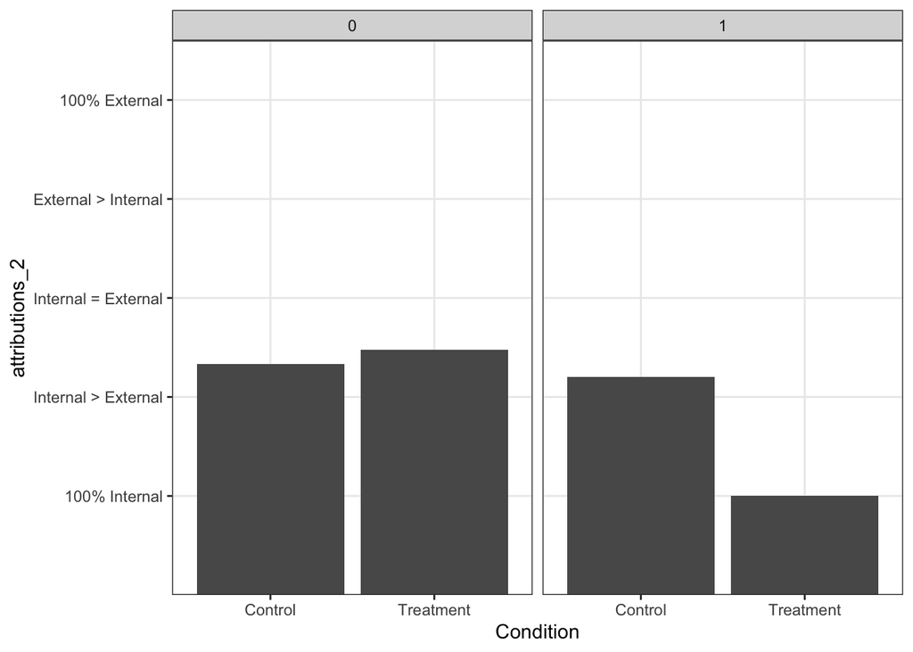

```r
data %>%
  filter(!is.na(race_urm)) %>%
ggplot(aes(x=Condition, y=attributions_2)) +
  facet_wrap(~race_urm) +
  geom_bar(stat="summary", position="dodge") +
  scale_y_discrete(limit = c("100% Internal", "Internal > External", "Internal = External", "External > Internal", "100% External")) +
  theme_bw()
```

### Perspective-Taking 🔴

```r
t.test(data$IRI_PT1_2 ~ data$Condition)
```

```
    Welch Two Sample t-test

data:  data$IRI_PT1_2 by data$Condition
t = -0.64391, df = 64.238, p-value = 0.5219
alternative hypothesis: true difference in means between group Control and group Treatment is not equal to 0
95 percent confidence interval:
 -0.5549497  0.2843927
sample estimates:
  mean in group Control mean in group Treatment
               3.692308                3.827586
```

```r
summary(lm(IRI_PT1_2 ~ Condition + gender, data))
```

```
Call:
lm(formula = IRI_PT1_2 ~ Condition + gender, data = data)

Residuals:
    Min      1Q  Median      3Q     Max
-1.9031 -0.6469  0.2012  0.3532  1.3532

Coefficients:
                   Estimate Std. Error t value Pr(>|t|)
(Intercept)          3.5426     0.2110  16.788   <2e-16 ***
ConditionTreatment   0.1520     0.2153   0.706    0.483
gender               0.1043     0.1099   0.949    0.346
---
Signif. codes:  0 '***' 0.001 '**' 0.01 '*' 0.05 '.' 0.1 ' ' 1

Residual standard error: 0.8749 on 65 degrees of freedom
  (45 observations deleted due to missingness)
Multiple R-squared:  0.01958,   Adjusted R-squared:  -0.01059
F-statistic: 0.6491 on 2 and 65 DF,  p-value: 0.5259
```

```r
summary(lm(IRI_PT1_2 ~ Condition + manager_text, data))
```

```
Call:
lm(formula = IRI_PT1_2 ~ Condition + manager_text, data = data)

Residuals:
    Min      1Q  Median      3Q     Max
-1.8462 -0.6752  0.1855  0.3248  1.3248

Coefficients:
                   Estimate Std. Error t value Pr(>|t|)
(Intercept)         3.67523    0.18260  20.128   <2e-16 ***
ConditionTreatment  0.13923    0.21764   0.640    0.525
manager_textYes     0.03172    0.21537   0.147    0.883
---
Signif. codes:  0 '***' 0.001 '**' 0.01 '*' 0.05 '.' 0.1 ' ' 1

Residual standard error: 0.8808 on 65 degrees of freedom
  (45 observations deleted due to missingness)
Multiple R-squared:  0.006329,  Adjusted R-squared:  -0.02425
F-statistic: 0.207 on 2 and 65 DF,  p-value: 0.8135
```

```r
summary(lm(IRI_PT1_2 ~ Condition * race_urm, data))
```

```
Call:
lm(formula = IRI_PT1_2 ~ Condition * race_urm, data = data)

Residuals:
    Min      1Q  Median      3Q     Max
-1.7667 -0.5000  0.2333  0.2500  1.6000

Coefficients:
                            Estimate Std. Error t value Pr(>|t|)
(Intercept)                  3.76667    0.16324  23.074   <2e-16 ***
ConditionTreatment          -0.01667    0.24486  -0.068    0.946
race_urm                    -0.36667    0.43189  -0.849    0.399
ConditionTreatment:race_urm  1.11667    0.78711   1.419    0.161
---
Signif. codes:  0 '***' 0.001 '**' 0.01 '*' 0.05 '.' 0.1 ' ' 1

Residual standard error: 0.8941 on 57 degrees of freedom
  (52 observations deleted due to missingness)
Multiple R-squared:  0.03688,   Adjusted R-squared:  -0.01381
F-statistic: 0.7275 on 3 and 57 DF,  p-value: 0.5398
```

```r
t.test(data$IRI_PT2_2 ~ data$Condition)
```

```
    Welch Two Sample t-test

data:  data$IRI_PT2_2 by data$Condition
t = -0.44529, df = 61.926, p-value = 0.6577
alternative hypothesis: true difference in means between group Control and group Treatment is not equal to 0
95 percent confidence interval:
 -0.5096101  0.3239337
sample estimates:
  mean in group Control mean in group Treatment
               3.769231                3.862069
```

```r
summary(lm(IRI_PT2_2 ~ Condition + gender, data))
```

```
Call:
lm(formula = IRI_PT2_2 ~ Condition + gender, data = data)

Residuals:
     Min       1Q   Median       3Q      Max
-1.91950 -0.07826  0.15981  0.26534  1.26534

Coefficients:
                   Estimate Std. Error t value Pr(>|t|)
(Intercept)          3.6554     0.2072  17.642   <2e-16 ***
ConditionTreatment   0.1055     0.2114   0.499    0.619
gender               0.0793     0.1079   0.735    0.465
---
Signif. codes:  0 '***' 0.001 '**' 0.01 '*' 0.05 '.' 0.1 ' ' 1

Residual standard error: 0.8591 on 65 degrees of freedom
  (45 observations deleted due to missingness)
Multiple R-squared:  0.01117,   Adjusted R-squared:  -0.01925
F-statistic: 0.3672 on 2 and 65 DF,  p-value: 0.6941
```

```r
summary(lm(IRI_PT2_2 ~ Condition + manager_text, data))
```

```
Call:
lm(formula = IRI_PT2_2 ~ Condition + manager_text, data = data)

Residuals:
    Min      1Q  Median      3Q     Max
-1.8744  0.1256  0.1851  0.2445  1.2445

Coefficients:
                   Estimate Std. Error t value Pr(>|t|)
(Intercept)         3.78528    0.17880  21.170   <2e-16 ***
ConditionTreatment  0.08912    0.21312   0.418    0.677
manager_textYes    -0.02981    0.21089  -0.141    0.888
---
Signif. codes:  0 '***' 0.001 '**' 0.01 '*' 0.05 '.' 0.1 ' ' 1

Residual standard error: 0.8625 on 65 degrees of freedom
  (45 observations deleted due to missingness)
Multiple R-squared:  0.003261,  Adjusted R-squared:  -0.02741
F-statistic: 0.1063 on 2 and 65 DF,  p-value: 0.8993
```

```r
summary(lm(IRI_PT2_2 ~ Condition * race_urm, data))
```

```
Call:
lm(formula = IRI_PT2_2 ~ Condition * race_urm, data = data)

Residuals:
     Min       1Q   Median       3Q      Max
-1.93333  0.00000  0.06667  0.20833  1.60000

Coefficients:
                            Estimate Std. Error t value Pr(>|t|)
(Intercept)                   3.9333     0.1511  26.037   <2e-16 ***
ConditionTreatment           -0.1417     0.2266  -0.625    0.534
race_urm                     -0.5333     0.3997  -1.334    0.187
ConditionTreatment:race_urm   0.7417     0.7284   1.018    0.313
---
Signif. codes:  0 '***' 0.001 '**' 0.01 '*' 0.05 '.' 0.1 ' ' 1

Residual standard error: 0.8274 on 57 degrees of freedom
  (52 observations deleted due to missingness)
Multiple R-squared:  0.03309,   Adjusted R-squared:  -0.0178
F-statistic: 0.6503 on 3 and 57 DF,  p-value: 0.586
```

## $\Delta$ Scenario 1 - Scenario 2 🔴

### Attributions

```r
t.test(data$attributionsDiff ~ data$Condition)
```

```
    Welch Two Sample t-test

data:  data$attributionsDiff by data$Condition
t = -1.3453, df = 50.119, p-value = 0.1846
alternative hypothesis: true difference in means between group Control and group Treatment is not equal to 0
95 percent confidence interval:
 -0.9177186  0.1814548
sample estimates:
  mean in group Control mean in group Treatment
              0.8461538               1.2142857
```

```r
summary(lm(attributionsDiff ~ Condition + gender, data))
```

```
Call:
lm(formula = attributionsDiff ~ Condition + gender, data = data)

Residuals:
    Min      1Q  Median      3Q     Max
-2.1741 -0.7849 -0.1741  0.8259  2.8259

Coefficients:
                   Estimate Std. Error t value Pr(>|t|)
(Intercept)          0.6443     0.2569   2.508   0.0147 *
ConditionTreatment   0.3892     0.2645   1.472   0.1460
gender               0.1406     0.1338   1.051   0.2973
---
Signif. codes:  0 '***' 0.001 '**' 0.01 '*' 0.05 '.' 0.1 ' ' 1

Residual standard error: 1.065 on 64 degrees of freedom
  (46 observations deleted due to missingness)
Multiple R-squared:  0.04553,   Adjusted R-squared:  0.0157
F-statistic: 1.526 on 2 and 64 DF,  p-value: 0.2251
```

```r
summary(lm(attributionsDiff ~ Condition + manager_text, data))
```

```
Call:
lm(formula = attributionsDiff ~ Condition + manager_text, data = data)

Residuals:
     Min       1Q   Median       3Q      Max
-2.02417 -0.70163 -0.02417  0.66270  2.66270

Coefficients:
                   Estimate Std. Error t value Pr(>|t|)
(Intercept)          1.0148     0.2211   4.589 2.13e-05 ***
ConditionTreatment   0.3225     0.2658   1.213    0.229
manager_textYes     -0.3131     0.2625  -1.193    0.237
---
Signif. codes:  0 '***' 0.001 '**' 0.01 '*' 0.05 '.' 0.1 ' ' 1

Residual standard error: 1.062 on 64 degrees of freedom
  (46 observations deleted due to missingness)
Multiple R-squared:  0.05019,   Adjusted R-squared:  0.0205
F-statistic: 1.691 on 2 and 64 DF,  p-value: 0.1925
```

```r
summary(lm(attributionsDiff ~ Condition * race_urm, data))
```

```
Call:
lm(formula = attributionsDiff ~ Condition * race_urm, data = data)

Residuals:
     Min       1Q   Median       3Q      Max
-1.93333 -0.91304  0.06667  1.06667  2.06667

Coefficients:
                            Estimate Std. Error t value Pr(>|t|)
(Intercept)                  0.93333    0.16990   5.494 9.97e-07 ***
ConditionTreatment          -0.02029    0.25790  -0.079 0.937574
race_urm                    -0.13333    0.44950  -0.297 0.767851
ConditionTreatment:race_urm  3.22029    0.82017   3.926 0.000239 ***
---
Signif. codes:  0 '***' 0.001 '**' 0.01 '*' 0.05 '.' 0.1 ' ' 1

Residual standard error: 0.9306 on 56 degrees of freedom
  (53 observations deleted due to missingness)
Multiple R-squared:  0.276, Adjusted R-squared:  0.2373
F-statistic: 7.118 on 3 and 56 DF,  p-value: 0.0003914
```

```
No summary function supplied, defaulting to `mean_se()`
No summary function supplied, defaulting to `mean_se()`
```

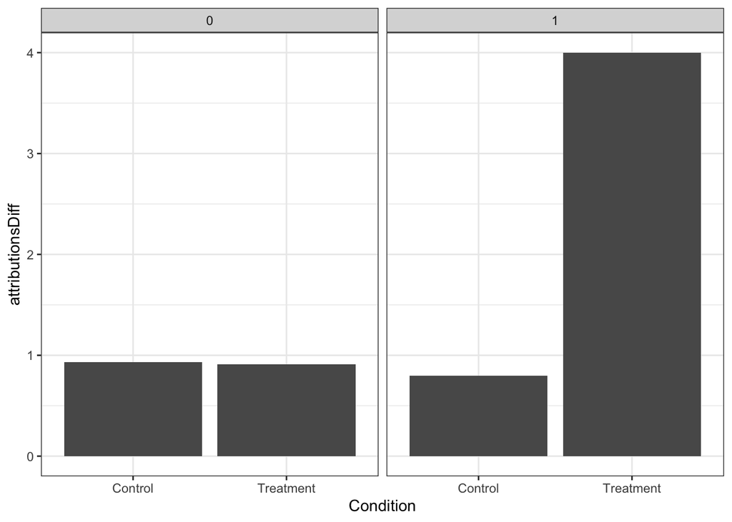

```r
data %>%
  filter(!is.na(race_urm)) %>%
ggplot(aes(x=Condition, y=attributionsDiff)) +
  facet_wrap(~race_urm) +
  geom_bar(stat="summary", position="dodge") +
  theme_bw()
```

### Perspective-Taking

```r
t.test(data$IRI_PT1Diff ~ data$Condition)
```

```
    Welch Two Sample t-test

data:  data$IRI_PT1Diff by data$Condition
t = -0.64391, df = 64.238, p-value = 0.5219
alternative hypothesis: true difference in means between group Control and group Treatment is not equal to 0
95 percent confidence interval:
 -0.5549497  0.2843927
sample estimates:
  mean in group Control mean in group Treatment
               3.692308                3.827586
```

```r
summary(lm(IRI_PT1Diff ~ Condition + gender, data))
```

```
Call:
lm(formula = IRI_PT1Diff ~ Condition + gender, data = data)

Residuals:
    Min      1Q  Median      3Q     Max
-1.9031 -0.6469  0.2012  0.3532  1.3532

Coefficients:
                   Estimate Std. Error t value Pr(>|t|)
(Intercept)          3.5426     0.2110  16.788   <2e-16 ***
ConditionTreatment   0.1520     0.2153   0.706    0.483
gender               0.1043     0.1099   0.949    0.346
---
Signif. codes:  0 '***' 0.001 '**' 0.01 '*' 0.05 '.' 0.1 ' ' 1

Residual standard error: 0.8749 on 65 degrees of freedom
  (45 observations deleted due to missingness)
Multiple R-squared:  0.01958,   Adjusted R-squared:  -0.01059
F-statistic: 0.6491 on 2 and 65 DF,  p-value: 0.5259
```

```r
summary(lm(IRI_PT1Diff ~ Condition + manager_text, data))
```

```
Call:
lm(formula = IRI_PT1Diff ~ Condition + manager_text, data = data)

Residuals:
    Min      1Q  Median      3Q     Max
-1.8462 -0.6752  0.1855  0.3248  1.3248

Coefficients:
                   Estimate Std. Error t value Pr(>|t|)
(Intercept)         3.67523    0.18260  20.128   <2e-16 ***
ConditionTreatment  0.13923    0.21764   0.640    0.525
manager_textYes     0.03172    0.21537   0.147    0.883
---
Signif. codes:  0 '***' 0.001 '**' 0.01 '*' 0.05 '.' 0.1 ' ' 1

Residual standard error: 0.8808 on 65 degrees of freedom
  (45 observations deleted due to missingness)
Multiple R-squared:  0.006329,  Adjusted R-squared:  -0.02425
F-statistic: 0.207 on 2 and 65 DF,  p-value: 0.8135
```

```r
summary(lm(IRI_PT1Diff ~ Condition * race_urm, data))
```

```
Call:
lm(formula = IRI_PT1Diff ~ Condition * race_urm, data = data)

Residuals:
    Min      1Q  Median      3Q     Max
-1.7667 -0.5000  0.2333  0.2500  1.6000

Coefficients:
                            Estimate Std. Error t value Pr(>|t|)
(Intercept)                  3.76667    0.16324  23.074   <2e-16 ***
ConditionTreatment          -0.01667    0.24486  -0.068    0.946
race_urm                    -0.36667    0.43189  -0.849    0.399
ConditionTreatment:race_urm  1.11667    0.78711   1.419    0.161
---
Signif. codes:  0 '***' 0.001 '**' 0.01 '*' 0.05 '.' 0.1 ' ' 1

Residual standard error: 0.8941 on 57 degrees of freedom
  (52 observations deleted due to missingness)
Multiple R-squared:  0.03688,   Adjusted R-squared:  -0.01381
F-statistic: 0.7275 on 3 and 57 DF,  p-value: 0.5398
```

```r
t.test(data$IRI_PT2Diff ~ data$Condition)
```

```
    Welch Two Sample t-test

data:  data$IRI_PT2Diff by data$Condition
t = -0.44529, df = 61.926, p-value = 0.6577
alternative hypothesis: true difference in means between group Control and group Treatment is not equal to 0
95 percent confidence interval:
 -0.5096101  0.3239337
sample estimates:
  mean in group Control mean in group Treatment
               3.769231                3.862069
```

```r
summary(lm(IRI_PT2Diff ~ Condition + gender, data))
```

```
Call:
lm(formula = IRI_PT2Diff ~ Condition + gender, data = data)

Residuals:
     Min       1Q   Median       3Q      Max
-1.91950 -0.07826  0.15981  0.26534  1.26534

Coefficients:
                   Estimate Std. Error t value Pr(>|t|)
(Intercept)          3.6554     0.2072  17.642   <2e-16 ***
ConditionTreatment   0.1055     0.2114   0.499    0.619
gender               0.0793     0.1079   0.735    0.465
---
Signif. codes:  0 '***' 0.001 '**' 0.01 '*' 0.05 '.' 0.1 ' ' 1

Residual standard error: 0.8591 on 65 degrees of freedom
  (45 observations deleted due to missingness)
Multiple R-squared:  0.01117,   Adjusted R-squared:  -0.01925
F-statistic: 0.3672 on 2 and 65 DF,  p-value: 0.6941
```

```r
summary(lm(IRI_PT2Diff ~ Condition + manager_text, data))
```

```
Call:
lm(formula = IRI_PT2Diff ~ Condition + manager_text, data = data)

Residuals:
    Min      1Q  Median      3Q     Max
-1.8744  0.1256  0.1851  0.2445  1.2445

Coefficients:
                   Estimate Std. Error t value Pr(>|t|)
(Intercept)         3.78528    0.17880  21.170   <2e-16 ***
ConditionTreatment  0.08912    0.21312   0.418    0.677
manager_textYes    -0.02981    0.21089  -0.141    0.888
---
Signif. codes:  0 '***' 0.001 '**' 0.01 '*' 0.05 '.' 0.1 ' ' 1

Residual standard error: 0.8625 on 65 degrees of freedom
  (45 observations deleted due to missingness)
Multiple R-squared:  0.003261,  Adjusted R-squared:  -0.02741
F-statistic: 0.1063 on 2 and 65 DF,  p-value: 0.8993
```

```r
summary(lm(IRI_PT2Diff ~ Condition * race_urm, data))
```

```
Call:
lm(formula = IRI_PT2Diff ~ Condition * race_urm, data = data)

Residuals:
     Min       1Q   Median       3Q      Max
-1.93333  0.00000  0.06667  0.20833  1.60000

Coefficients:
                            Estimate Std. Error t value Pr(>|t|)
(Intercept)                   3.9333     0.1511  26.037   <2e-16 ***
ConditionTreatment           -0.1417     0.2266  -0.625    0.534
race_urm                     -0.5333     0.3997  -1.334    0.187
ConditionTreatment:race_urm   0.7417     0.7284   1.018    0.313
---
Signif. codes:  0 '***' 0.001 '**' 0.01 '*' 0.05 '.' 0.1 ' ' 1

Residual standard error: 0.8274 on 57 degrees of freedom
  (52 observations deleted due to missingness)
Multiple R-squared:  0.03309,   Adjusted R-squared:  -0.0178
F-statistic: 0.6503 on 3 and 57 DF,  p-value: 0.586
```

# Session 2

#### Condition

| Condition | Freq |
| --- | --- |
| Control | 20 |
| Treatment | 17 |

#### Race

| URM | Freq |
| --- | --- |
| 0 | 31 |
| 1 | 3 |

#### Gender

| URM | Freq |
| --- | --- |
| 1 | 27 |
| 2 | 7 |
| 5 | 3 |

#### Manager

| URM | Freq |
| --- | --- |
| No | 21 |
| Yes | 16 |

## Perspective-taking

### a. 🟡

```
    Welch Two Sample t-test

data:  data$IRI_PT_1_S2 by data$Condition
t = 1.9985, df = 30.791, p-value = 0.05456
alternative hypothesis: true difference in means between group Control and group Treatment is not equal to 0
95 percent confidence interval:
 -0.01179952  1.14513286
sample estimates:
  mean in group Control mean in group Treatment
               2.500000                1.933333
```

```
No summary function supplied, defaulting to `mean_se()`
```

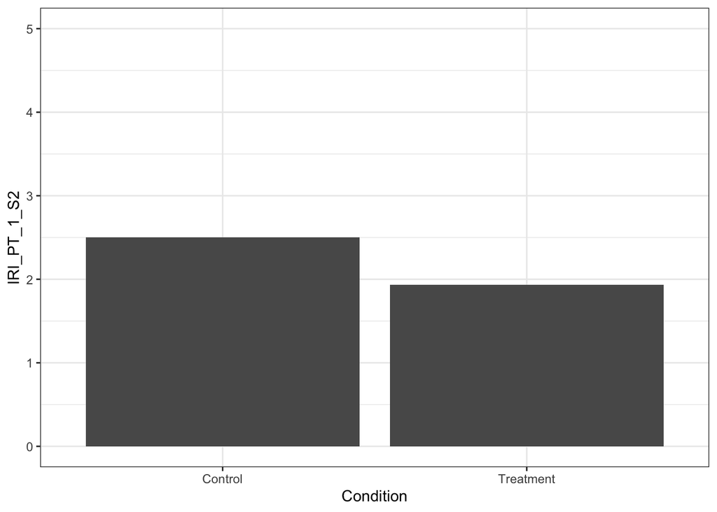

```
Call:
lm(formula = IRI_PT_1_S2 ~ Condition + gender, data = data)

Residuals:
    Min      1Q  Median      3Q     Max
-1.5421 -0.5421  0.0345  0.4579  2.0345

Coefficients:
                   Estimate Std. Error t value Pr(>|t|)
(Intercept)         2.61104    0.28466   9.173 3.29e-10 ***
ConditionTreatment -0.57662    0.29463  -1.957   0.0597 .
gender             -0.06892    0.12679  -0.544   0.5907
---
Signif. codes:  0 '***' 0.001 '**' 0.01 '*' 0.05 '.' 0.1 ' ' 1

Residual standard error: 0.8411 on 30 degrees of freedom
  (80 observations deleted due to missingness)
Multiple R-squared:  0.1179,    Adjusted R-squared:  0.05908
F-statistic: 2.005 on 2 and 30 DF,  p-value: 0.1524
```

```
Call:
lm(formula = IRI_PT_1_S2 ~ Condition + manager_text, data = data)

Residuals:
    Min      1Q  Median      3Q     Max
-1.5587 -0.5587  0.1215  0.4413  2.0040

Coefficients:
                   Estimate Std. Error t value Pr(>|t|)
(Intercept)          2.4413     0.2471   9.880 6.06e-11 ***
ConditionTreatment  -0.5628     0.2949  -1.908   0.0659 .
manager_textYes      0.1174     0.2938   0.400   0.6923
---
Signif. codes:  0 '***' 0.001 '**' 0.01 '*' 0.05 '.' 0.1 ' ' 1

Residual standard error: 0.843 on 30 degrees of freedom
  (80 observations deleted due to missingness)
Multiple R-squared:  0.1139,    Adjusted R-squared:  0.05484
F-statistic: 1.928 on 2 and 30 DF,  p-value: 0.163
```

```
Call:
lm(formula = IRI_PT_1_S2 ~ Condition + race_urm, data = data)

Residuals:
     Min       1Q   Median       3Q      Max
-0.92857 -0.64286  0.07143  0.35714  2.07143

Coefficients:
                   Estimate Std. Error t value Pr(>|t|)
(Intercept)          2.6429     0.1968  13.428 1.82e-13 ***
ConditionTreatment  -0.7143     0.2783  -2.566   0.0161 *
race_urm            -1.1429     0.5567  -2.053   0.0499 *
---
Signif. codes:  0 '***' 0.001 '**' 0.01 '*' 0.05 '.' 0.1 ' ' 1

Residual standard error: 0.7364 on 27 degrees of freedom
  (83 observations deleted due to missingness)
Multiple R-squared:  0.2439,    Adjusted R-squared:  0.1879
F-statistic: 4.355 on 2 and 27 DF,  p-value: 0.02295
```

### b. 🟢

```
    Welch Two Sample t-test

data:  data$IRI_PT_2_S2 by data$Condition
t = -3.0199, df = 30.627, p-value = 0.005064
alternative hypothesis: true difference in means between group Control and group Treatment is not equal to 0
95 percent confidence interval:
 -0.9495570 -0.1837764
sample estimates:
  mean in group Control mean in group Treatment
               4.166667                4.733333
```

```
No summary function supplied, defaulting to `mean_se()`
```

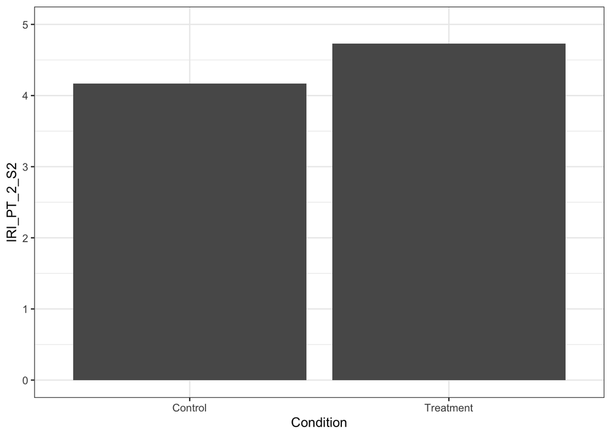

```
Call:
lm(formula = IRI_PT_2_S2 ~ Condition + gender, data = data)

Residuals:
    Min      1Q  Median      3Q     Max
-1.1051 -0.2634  0.1928  0.1928  0.8949

Coefficients:
                   Estimate Std. Error t value Pr(>|t|)
(Intercept)         4.42169    0.17834  24.794  < 2e-16 ***
ConditionTreatment  0.54380    0.18458   2.946  0.00617 **
gender             -0.15829    0.07943  -1.993  0.05545 .
---
Signif. codes:  0 '***' 0.001 '**' 0.01 '*' 0.05 '.' 0.1 ' ' 1

Residual standard error: 0.527 on 30 degrees of freedom
  (80 observations deleted due to missingness)
Multiple R-squared:  0.3093,    Adjusted R-squared:  0.2632
F-statistic: 6.716 on 2 and 30 DF,  p-value: 0.003887
```

```
Call:
lm(formula = IRI_PT_2_S2 ~ Condition + manager_text, data = data)

Residuals:
     Min       1Q   Median       3Q      Max
-0.96221 -0.37112  0.03779  0.45749  1.03779

Coefficients:
                   Estimate Std. Error t value Pr(>|t|)
(Intercept)          3.9622     0.1519  26.084  < 2e-16 ***
ConditionTreatment   0.5803     0.1813   3.201  0.00323 **
manager_textYes      0.4089     0.1806   2.264  0.03096 *
---
Signif. codes:  0 '***' 0.001 '**' 0.01 '*' 0.05 '.' 0.1 ' ' 1

Residual standard error: 0.5182 on 30 degrees of freedom
  (80 observations deleted due to missingness)
Multiple R-squared:  0.332, Adjusted R-squared:  0.2874
F-statistic: 7.455 on 2 and 30 DF,  p-value: 0.002354
```

```
Call:
lm(formula = IRI_PT_2_S2 ~ Condition + race_urm, data = data)

Residuals:
     Min       1Q   Median       3Q      Max
-1.07143 -0.07143  0.07143  0.21429  0.92857

Coefficients:
                   Estimate Std. Error t value Pr(>|t|)
(Intercept)          4.0714     0.1435  28.369  < 2e-16 ***
ConditionTreatment   0.7143     0.2030   3.519  0.00155 **
race_urm             0.4286     0.4059   1.056  0.30042
---
Signif. codes:  0 '***' 0.001 '**' 0.01 '*' 0.05 '.' 0.1 ' ' 1

Residual standard error: 0.537 on 27 degrees of freedom
  (83 observations deleted due to missingness)
Multiple R-squared:  0.315, Adjusted R-squared:  0.2643
F-statistic: 6.209 on 2 and 27 DF,  p-value: 0.006046
```

### c. 🔴 / 🟢 with URM as covariate

```
    Welch Two Sample t-test

data:  data$IRI_PT_3_S2 by data$Condition
t = -1.5174, df = 30.354, p-value = 0.1395
alternative hypothesis: true difference in means between group Control and group Treatment is not equal to 0
95 percent confidence interval:
 -0.8859752  0.1304196
sample estimates:
  mean in group Control mean in group Treatment
               3.888889                4.266667
```

```
Call:
lm(formula = IRI_PT_3_S2 ~ Condition + gender, data = data)

Residuals:
     Min       1Q   Median       3Q      Max
-1.83901 -0.32652  0.03274  0.67348  1.03274

Coefficients:
                   Estimate Std. Error t value Pr(>|t|)
(Intercept)          4.0955     0.2471  16.577   <2e-16 ***
ConditionTreatment   0.3593     0.2557   1.405    0.170
gender              -0.1283     0.1100  -1.166    0.253
---
Signif. codes:  0 '***' 0.001 '**' 0.01 '*' 0.05 '.' 0.1 ' ' 1

Residual standard error: 0.73 on 30 degrees of freedom
  (80 observations deleted due to missingness)
Multiple R-squared:  0.1058,    Adjusted R-squared:  0.04619
F-statistic: 1.775 on 2 and 30 DF,  p-value: 0.1869
```

```
Call:
lm(formula = IRI_PT_3_S2 ~ Condition + manager_text, data = data)

Residuals:
     Min       1Q   Median       3Q      Max
-1.75933 -0.40486 -0.01844  0.59514  1.24067

Coefficients:
                   Estimate Std. Error t value Pr(>|t|)
(Intercept)          3.7593     0.2151  17.475   <2e-16 ***
ConditionTreatment   0.3864     0.2567   1.505    0.143
manager_textYes      0.2591     0.2558   1.013    0.319
---
Signif. codes:  0 '***' 0.001 '**' 0.01 '*' 0.05 '.' 0.1 ' ' 1

Residual standard error: 0.7339 on 30 degrees of freedom
  (80 observations deleted due to missingness)
Multiple R-squared:  0.09623,   Adjusted R-squared:  0.03598
F-statistic: 1.597 on 2 and 30 DF,  p-value: 0.2192
```

```
Call:
lm(formula = IRI_PT_3_S2 ~ Condition + race_urm, data = data)

Residuals:
     Min       1Q   Median       3Q      Max
-1.64286 -0.28571  0.03571  0.35714  1.35714

Coefficients:
                   Estimate Std. Error t value Pr(>|t|)
(Intercept)          3.6429     0.1824  19.975   <2e-16 ***
ConditionTreatment   0.6429     0.2579   2.493   0.0191 *
race_urm             0.8571     0.5158   1.662   0.1081
---
Signif. codes:  0 '***' 0.001 '**' 0.01 '*' 0.05 '.' 0.1 ' ' 1

Residual standard error: 0.6824 on 27 degrees of freedom
  (83 observations deleted due to missingness)
Multiple R-squared:  0.2143,    Adjusted R-squared:  0.1561
F-statistic: 3.682 on 2 and 27 DF,  p-value: 0.03855
```

### d. 🔴

```
    Welch Two Sample t-test

data:  data$IRI_PT_4_S2 by data$Condition
t = -0.63621, df = 30.728, p-value = 0.5294
alternative hypothesis: true difference in means between group Control and group Treatment is not equal to 0
95 percent confidence interval:
 -0.5609174  0.2942508
sample estimates:
  mean in group Control mean in group Treatment
               4.000000                4.133333
```

```
Call:
lm(formula = IRI_PT_4_S2 ~ Condition + gender, data = data)

Residuals:
     Min       1Q   Median       3Q      Max
-1.15383 -0.15383 -0.02685  0.14887  1.01708

Coefficients:
                   Estimate Std. Error t value Pr(>|t|)
(Intercept)         4.07077    0.21088  19.304   <2e-16 ***
ConditionTreatment  0.12699    0.21827   0.582    0.565
gender             -0.04393    0.09393  -0.468    0.643
---
Signif. codes:  0 '***' 0.001 '**' 0.01 '*' 0.05 '.' 0.1 ' ' 1

Residual standard error: 0.6231 on 30 degrees of freedom
  (80 observations deleted due to missingness)
Multiple R-squared:  0.01939,   Adjusted R-squared:  -0.04598
F-statistic: 0.2967 on 2 and 30 DF,  p-value: 0.7454
```

```
Call:
lm(formula = IRI_PT_4_S2 ~ Condition + manager_text, data = data)

Residuals:
     Min       1Q   Median       3Q      Max
-1.13765 -0.13765 -0.00405  0.00405  1.00405

Coefficients:
                   Estimate Std. Error t value Pr(>|t|)
(Intercept)        3.995951   0.183310  21.799   <2e-16 ***
ConditionTreatment 0.133603   0.218753   0.611    0.546
manager_textYes    0.008097   0.217948   0.037    0.971
---
Signif. codes:  0 '***' 0.001 '**' 0.01 '*' 0.05 '.' 0.1 ' ' 1

Residual standard error: 0.6254 on 30 degrees of freedom
  (80 observations deleted due to missingness)
Multiple R-squared:  0.01229,   Adjusted R-squared:  -0.05356
F-statistic: 0.1866 on 2 and 30 DF,  p-value: 0.8307
```

```
Call:
lm(formula = IRI_PT_4_S2 ~ Condition + race_urm, data = data)

Residuals:
    Min      1Q  Median      3Q     Max
-1.1429 -0.1429 -0.1429  0.2143  1.2143

Coefficients:
                   Estimate Std. Error t value Pr(>|t|)
(Intercept)          3.7857     0.1506  25.140   <2e-16 ***
ConditionTreatment   0.3571     0.2130   1.677    0.105
race_urm             0.7143     0.4259   1.677    0.105
---
Signif. codes:  0 '***' 0.001 '**' 0.01 '*' 0.05 '.' 0.1 ' ' 1

Residual standard error: 0.5634 on 27 degrees of freedom
  (83 observations deleted due to missingness)
Multiple R-squared:  0.1429,    Adjusted R-squared:  0.07937
F-statistic:  2.25 on 2 and 27 DF,  p-value: 0.1248
```

## Relationships

### a. 🟢

*It is important to maintain a positive relationship with co-workers who are hard to work with.*

```
    Welch Two Sample t-test

data:  data$workerRelations1_recode_S2 by data$Condition
t = -2.8898, df = 29.929, p-value = 0.007106
alternative hypothesis: true difference in means between group Control and group Treatment is not equal to 0
95 percent confidence interval:
 -1.0999270 -0.1889619
sample estimates:
  mean in group Control mean in group Treatment
               3.888889                4.533333
```

```
No summary function supplied, defaulting to `mean_se()`
```

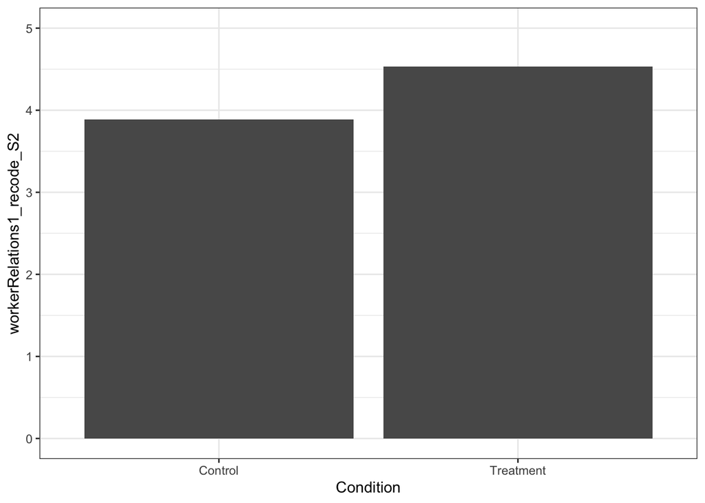

```
Call:
lm(formula = workerRelations1_recode_S2 ~ Condition + gender,
    data = data)

Residuals:
     Min       1Q   Median       3Q      Max
-0.92376 -0.55996  0.07624  0.44004  1.30447

Coefficients:
                   Estimate Std. Error t value Pr(>|t|)
(Intercept)         3.98081    0.22591  17.621   <2e-16 ***
ConditionTreatment  0.63620    0.23382   2.721   0.0107 *
gender             -0.05706    0.10062  -0.567   0.5749
---
Signif. codes:  0 '***' 0.001 '**' 0.01 '*' 0.05 '.' 0.1 ' ' 1

Residual standard error: 0.6675 on 30 degrees of freedom
  (80 observations deleted due to missingness)
Multiple R-squared:  0.2094,    Adjusted R-squared:  0.1567
F-statistic: 3.974 on 2 and 30 DF,  p-value: 0.02945
```

```
Call:
lm(formula = workerRelations1_recode_S2 ~ Condition + manager_text,
    data = data)

Residuals:
     Min       1Q   Median       3Q      Max
-1.02654 -0.68016 -0.02654  0.31984  1.24876

Coefficients:
                   Estimate Std. Error t value Pr(>|t|)
(Intercept)          3.7512     0.1921  19.526  < 2e-16 ***
ConditionTreatment   0.6536     0.2293   2.851  0.00781 **
manager_textYes      0.2753     0.2284   1.205  0.23752
---
Signif. codes:  0 '***' 0.001 '**' 0.01 '*' 0.05 '.' 0.1 ' ' 1

Residual standard error: 0.6554 on 30 degrees of freedom
  (80 observations deleted due to missingness)
Multiple R-squared:  0.2379,    Adjusted R-squared:  0.1871
F-statistic: 4.681 on 2 and 30 DF,  p-value: 0.017
```

```
Call:
lm(formula = workerRelations1_recode_S2 ~ Condition + race_urm,
    data = data)

Residuals:
     Min       1Q   Median       3Q      Max
-0.92857 -0.57143  0.07143  0.42857  1.07143

Coefficients:
                   Estimate Std. Error t value Pr(>|t|)
(Intercept)          3.9286     0.1844  21.301   <2e-16 ***
ConditionTreatment   0.6429     0.2608   2.465   0.0204 *
race_urm            -0.4286     0.5216  -0.822   0.4185
---
Signif. codes:  0 '***' 0.001 '**' 0.01 '*' 0.05 '.' 0.1 ' ' 1

Residual standard error: 0.6901 on 27 degrees of freedom
  (83 observations deleted due to missingness)
Multiple R-squared:  0.2347,    Adjusted R-squared:  0.178
F-statistic:  4.14 on 2 and 27 DF,  p-value: 0.02703
```

### b. 🔴

*There are certain co-workers that I come into conflict with and nothing can be done to change that.*

```
    Welch Two Sample t-test

data:  data$workerRelations2_recode_S2 by data$Condition
t = 1.0359, df = 28.93, p-value = 0.3088
alternative hypothesis: true difference in means between group Control and group Treatment is not equal to 0
95 percent confidence interval:
 -0.411490  1.255934
sample estimates:
  mean in group Control mean in group Treatment
               3.222222                2.800000
```

```
Call:
lm(formula = workerRelations2_recode_S2 ~ Condition + gender,
    data = data)

Residuals:
    Min      1Q  Median      3Q     Max
-2.3339 -0.8853  0.1147  0.6661  2.1147

Coefficients:
                   Estimate Std. Error t value Pr(>|t|)
(Intercept)          3.5167     0.3910   8.995 5.08e-10 ***
ConditionTreatment  -0.4486     0.4047  -1.109    0.276
gender              -0.1828     0.1741  -1.050    0.302
---
Signif. codes:  0 '***' 0.001 '**' 0.01 '*' 0.05 '.' 0.1 ' ' 1

Residual standard error: 1.155 on 30 degrees of freedom
  (80 observations deleted due to missingness)
Multiple R-squared:  0.06816,   Adjusted R-squared:  0.006041
F-statistic: 1.097 on 2 and 30 DF,  p-value: 0.3468
```

```
Call:
lm(formula = workerRelations2_recode_S2 ~ Condition + manager_text,
    data = data)

Residuals:
    Min      1Q  Median      3Q     Max
-2.1372 -0.8907 -0.1372  0.8628  2.2793

Coefficients:
                   Estimate Std. Error t value Pr(>|t|)
(Intercept)          3.1372     0.3438   9.125 3.69e-10 ***
ConditionTreatment  -0.4166     0.4103  -1.015    0.318
manager_textYes      0.1700     0.4088   0.416    0.680
---
Signif. codes:  0 '***' 0.001 '**' 0.01 '*' 0.05 '.' 0.1 ' ' 1

Residual standard error: 1.173 on 30 degrees of freedom
  (80 observations deleted due to missingness)
Multiple R-squared:  0.03948,   Adjusted R-squared:  -0.02455
F-statistic: 0.6166 on 2 and 30 DF,  p-value: 0.5465
```

```
Call:
lm(formula = workerRelations2_recode_S2 ~ Condition + race_urm,
    data = data)

Residuals:
    Min      1Q  Median      3Q     Max
-2.4286 -0.8571  0.1429  0.5714  2.1429

Coefficients:
                   Estimate Std. Error t value Pr(>|t|)
(Intercept)          3.4286     0.3135  10.938 2.01e-11 ***
ConditionTreatment  -0.5714     0.4433  -1.289    0.208
race_urm            -0.4286     0.8866  -0.483    0.633
---
Signif. codes:  0 '***' 0.001 '**' 0.01 '*' 0.05 '.' 0.1 ' ' 1

Residual standard error: 1.173 on 27 degrees of freedom
  (83 observations deleted due to missingness)
Multiple R-squared:  0.05888,   Adjusted R-squared:  -0.01083
F-statistic: 0.8446 on 2 and 27 DF,  p-value: 0.4408
```

*A culture of harmonious working relationships is a top priority for me.*

```
    Welch Two Sample t-test

data:  data$workerRelations3_recode_S2 by data$Condition
t = -1.419, df = 30.481, p-value = 0.1661
alternative hypothesis: true difference in means between group Control and group Treatment is not equal to 0
95 percent confidence interval:
 -1.1378809  0.2045475
sample estimates:
  mean in group Control mean in group Treatment
               4.000000                4.466667
```

```
Call:
lm(formula = workerRelations3_recode_S2 ~ Condition + gender,
    data = data)

Residuals:
    Min      1Q  Median      3Q     Max
-2.5331 -0.3907  0.4669  0.4825  1.0554

Coefficients:
                   Estimate Std. Error t value Pr(>|t|)
(Intercept)          4.2294     0.3201  13.212 4.86e-14 ***
ConditionTreatment   0.4461     0.3313   1.346    0.188
gender              -0.1424     0.1426  -0.999    0.326
---
Signif. codes:  0 '***' 0.001 '**' 0.01 '*' 0.05 '.' 0.1 ' ' 1

Residual standard error: 0.9459 on 30 degrees of freedom
  (80 observations deleted due to missingness)
Multiple R-squared:  0.0906,    Adjusted R-squared:  0.02997
F-statistic: 1.494 on 2 and 30 DF,  p-value: 0.2406
```

```
Call:
lm(formula = workerRelations3_recode_S2 ~ Condition + manager_text,
    data = data)

Residuals:
     Min       1Q   Median       3Q      Max
-2.38462 -0.38462  0.07692  0.61538  1.07692

Coefficients:
                   Estimate Std. Error t value Pr(>|t|)
(Intercept)          4.0769     0.2808  14.517 4.17e-15 ***
ConditionTreatment   0.4615     0.3351   1.377    0.179
manager_textYes     -0.1538     0.3339  -0.461    0.648
---
Signif. codes:  0 '***' 0.001 '**' 0.01 '*' 0.05 '.' 0.1 ' ' 1

Residual standard error: 0.9581 on 30 degrees of freedom
  (80 observations deleted due to missingness)
Multiple R-squared:  0.06697,   Adjusted R-squared:  0.00477
F-statistic: 1.077 on 2 and 30 DF,  p-value: 0.3535
```

```
Call:
lm(formula = workerRelations3_recode_S2 ~ Condition + race_urm,
    data = data)

Residuals:
    Min      1Q  Median      3Q     Max
-2.5714 -0.4286  0.1429  0.4286  1.1429

Coefficients:
                   Estimate Std. Error t value Pr(>|t|)
(Intercept)          3.8571     0.2474  15.588 5.05e-15 ***
ConditionTreatment   0.7143     0.3499   2.041   0.0511 .
race_urm             0.1429     0.6999   0.204   0.8398
---
Signif. codes:  0 '***' 0.001 '**' 0.01 '*' 0.05 '.' 0.1 ' ' 1

Residual standard error: 0.9258 on 27 degrees of freedom
  (83 observations deleted due to missingness)
Multiple R-squared:  0.1365,    Adjusted R-squared:  0.07249
F-statistic: 2.133 on 2 and 27 DF,  p-value: 0.138
```

```
No summary function supplied, defaulting to `mean_se()`
No summary function supplied, defaulting to `mean_se()`
```

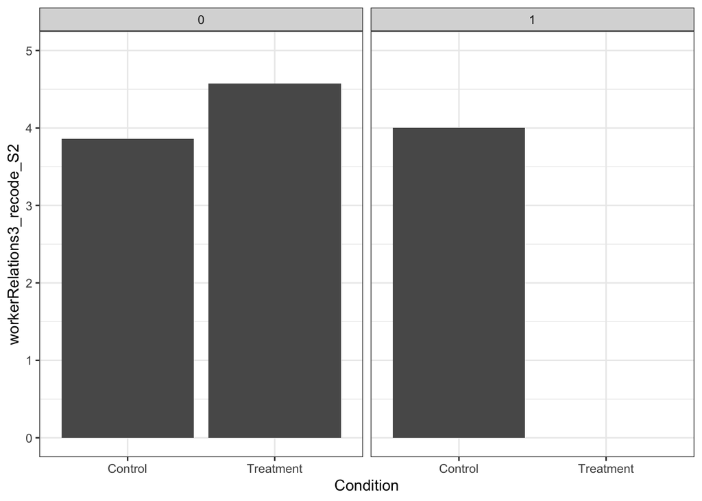

# Scenario

## Attributions 🔴

```r
t.test(data$attributions_S2 ~ data$Condition)
```

```
    Welch Two Sample t-test

data:  data$attributions_S2 by data$Condition
t = 1.4796, df = 14.479, p-value = 0.1604
alternative hypothesis: true difference in means between group Control and group Treatment is not equal to 0
95 percent confidence interval:
 -0.2457209  1.3497933
sample estimates:
  mean in group Control mean in group Treatment
               2.705882                2.153846
```

## Perspective-Taking 🟢

```r
t.test(data$IRI_PT1_S2 ~ data$Condition)
```

```
    Welch Two Sample t-test

data:  data$IRI_PT1_S2 by data$Condition
t = -0.55555, df = 15.857, p-value = 0.5863
alternative hypothesis: true difference in means between group Control and group Treatment is not equal to 0
95 percent confidence interval:
 -0.7631365  0.4463944
sample estimates:
  mean in group Control mean in group Treatment
               3.764706                3.923077
```

```r
t.test(data$IRI_PT2_S2 ~ data$Condition)
```

```
    Welch Two Sample t-test

data:  data$IRI_PT2_S2 by data$Condition
t = -3.084, df = 27.839, p-value = 0.004576
alternative hypothesis: true difference in means between group Control and group Treatment is not equal to 0
95 percent confidence interval:
 -1.0016431 -0.2019768
sample estimates:
  mean in group Control mean in group Treatment
               3.705882                4.307692
```

```
No summary function supplied, defaulting to `mean_se()`
```

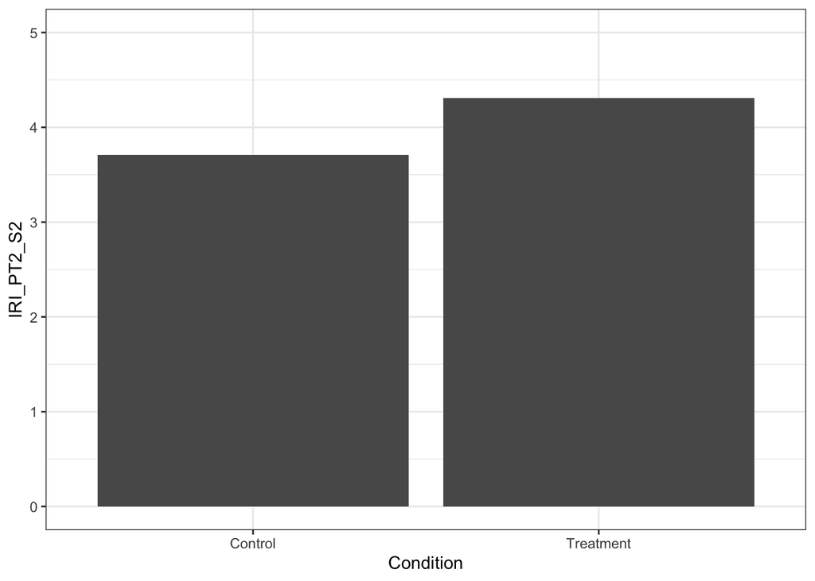

```r
data %>%
  filter(!is.na(Condition)) %>%
ggplot(aes(x=Condition, y=IRI_PT2_S2)) +
  geom_bar(stat="summary", position="dodge") +
  expand_limits(y = c(1, 5)) +
  theme_bw()
```

# Belonging 🔴

$\alpha = 0.87$

```
    Welch Two Sample t-test

data:  data$belonging_S2 by data$Condition
t = 0.39767, df = 28.101, p-value = 0.6939
alternative hypothesis: true difference in means between group Control and group Treatment is not equal to 0
95 percent confidence interval:
 -0.2831898  0.4196604
sample estimates:
  mean in group Control mean in group Treatment
               3.080000                3.011765
```

# Sense of Fit 🔴

$\alpha = 0.89$

```
    Welch Two Sample t-test

data:  data$fit_recode_S2 by data$Condition
t = -0.92155, df = 29.778, p-value = 0.3642
alternative hypothesis: true difference in means between group Control and group Treatment is not equal to 0
95 percent confidence interval:
 -2.0089383  0.7599187
sample estimates:
  mean in group Control mean in group Treatment
               3.983333                4.607843
```